# Churn-Modelling

### Business Problem

The organisation is a large financial institution that services a large number of customers. Recenly , the organisation has noticed an increase in customers who are leaving the organisation and would like to understand why this is happening as well as identify customers who are likely to churn in order to engage and retain those customers. As there is substantial costs involved with reaching customers, the organisation is interested in curating a list of customers to share with its marketing team to begin the engagement process.

### Problem Statement

There is a significant increase in customers churning over the last 12 months. The organisation is therefore looking to reduce customer churn to < 10% within the next 12 months with the expected benefit of increasing revenue by $55m in the next 12 months

### Data Science Activities

1. Conduct exploratory Analysis to understand drivers of Churn
2. Build an initial model to Identify customers likely to churn

### Results:

1. Feature importance refers to the importance of a feature in driving the outcome of churn for each of our respective models as shown above Across all models, Age appears to be the most important driver that impacts churn for our customers followed by their activity and number of products they possess

[figure not shown]

2. Both Random Forest Models and Gradient Boosting Models show very good overall performance with a AUC ROC (Area under Curve) score of .95 and .93. High score means both models are very good at identifying customers who will churn. Further, the models also have high recall and precision which is important because:
   - High Recall means lower likelihood of false negatives (we fail to identify churning customers) which is a bad outcome for retention
   - High Precision meaning lower likelihood of false positive (non-churning customers predicted as churning) which is costly to engage

[figure not shown]

### Import Libraries

```python
import pandas as pd # To work with Data frames
import numpy as np # To work with serialized data
import matplotlib.pyplot as plt # To generate visualisations
import seaborn as sns # To generate visualisations
from sklearn.model_selection import train_test_split # To split data
from sklearn.preprocessing import normalize,scale
from sklearn.linear_model import LogisticRegression
from sklearn.ensemble import RandomForestClassifier, GradientBoostingClassifier
from sklearn.tree import DecisionTreeClassifier, plot_tree # Non parameteric method for classification and regression - used to predect the value of target variable by learning simple decision rule
from sklearn.metrics import confusion_matrix, ConfusionMatrixDisplay, accuracy_score,recall_score , precision_score,f1_score,roc_auc_score,auc,roc_curve#General scoring metics
from sklearn.datasets import make_classification
from collections import Counter
from imblearn.over_sampling import SMOTE
```

```python
# Set Seed for randomisation
import random
random.seed(23)
```

```python
# Import Data
df = pd.read_csv("Customer-Churn-Records.csv")
```

```python
# Check Data sample
df.head()
```

|  | RowNumber | CustomerId | Surname | CreditScore | Geography | Gender | Age | Tenure | Balance | NumOfProducts | HasCrCard | IsActiveMember | EstimatedSalary | Exited | Complain | Satisfaction Score | Card Type | Point Earned |
| --- | --- | --- | --- | --- | --- | --- | --- | --- | --- | --- | --- | --- | --- | --- | --- | --- | --- | --- |
| 0 | 1 | 15634602 | Hargrave | 619 | NSW | Female | 42 | 2 | 0.00 | 1 | 1 | 1 | 101348.88 | 1 | 1 | 2 | DIAMOND | 464 |
| 1 | 2 | 15647311 | Hill | 608 | QLD | Female | 41 | 1 | 83807.86 | 1 | 0 | 1 | 112542.58 | 0 | 1 | 3 | DIAMOND | 456 |
| 2 | 3 | 15619304 | Onio | 502 | NSW | Female | 42 | 8 | 159660.80 | 3 | 1 | 0 | 113931.57 | 1 | 1 | 3 | DIAMOND | 377 |
| 3 | 4 | 15701354 | Boni | 699 | NSW | Female | 39 | 1 | 0.00 | 2 | 0 | 0 | 93826.63 | 0 | 0 | 5 | GOLD | 350 |
| 4 | 5 | 15737888 | Mitchell | 850 | QLD | Female | 43 | 2 | 125510.82 | 1 | 1 | 1 | 79084.10 | 0 | 0 | 5 | GOLD | 425 |

### Exploratory Data Analysis

```python
# Exploratory Data Analysis
df.info()
df.describe()
```

```
<class 'pandas.core.frame.DataFrame'>
RangeIndex: 10000 entries, 0 to 9999
Data columns (total 18 columns):
 #   Column              Non-Null Count  Dtype
---  ------              --------------  -----
 0   RowNumber           10000 non-null  int64
 1   CustomerId          10000 non-null  int64
 2   Surname             10000 non-null  object
 3   CreditScore         10000 non-null  int64
 4   Geography           10000 non-null  object
 5   Gender              10000 non-null  object
 6   Age                 10000 non-null  int64
 7   Tenure              10000 non-null  int64
 8   Balance             10000 non-null  float64
 9   NumOfProducts       10000 non-null  int64
 10  HasCrCard           10000 non-null  int64
 11  IsActiveMember      10000 non-null  int64
 12  EstimatedSalary     10000 non-null  float64
 13  Exited              10000 non-null  int64
 14  Complain            10000 non-null  int64
 15  Satisfaction Score  10000 non-null  int64
 16  Card Type           10000 non-null  object
 17  Point Earned        10000 non-null  int64
dtypes: float64(2), int64(12), object(4)
memory usage: 1.4+ MB
```

|  | RowNumber | CustomerId | CreditScore | Age | Tenure | Balance | NumOfProducts | HasCrCard | IsActiveMember | EstimatedSalary | Exited | Complain | Satisfaction Score | Point Earned |
| --- | --- | --- | --- | --- | --- | --- | --- | --- | --- | --- | --- | --- | --- | --- |
| count | 10000.00000 | 1.000000e+04 | 10000.000000 | 10000.000000 | 10000.000000 | 10000.000000 | 10000.000000 | 10000.00000 | 10000.000000 | 10000.000000 | 10000.000000 | 10000.000000 | 10000.000000 | 10000.000000 |
| mean | 5000.50000 | 1.569094e+07 | 650.528800 | 38.921800 | 5.012800 | 76485.889288 | 1.530200 | 0.70550 | 0.515100 | 100090.239881 | 0.203800 | 0.204400 | 3.013800 | 606.515100 |
| std | 2886.89568 | 7.193619e+04 | 96.653299 | 10.487806 | 2.892174 | 62397.405202 | 0.581654 | 0.45584 | 0.499797 | 57510.492818 | 0.402842 | 0.403283 | 1.405919 | 225.924839 |
| min | 1.00000 | 1.556570e+07 | 350.000000 | 18.000000 | 0.000000 | 0.000000 | 1.000000 | 0.00000 | 0.000000 | 11.580000 | 0.000000 | 0.000000 | 1.000000 | 119.000000 |
| 25% | 2500.75000 | 1.562853e+07 | 584.000000 | 32.000000 | 3.000000 | 0.000000 | 1.000000 | 0.00000 | 0.000000 | 51002.110000 | 0.000000 | 0.000000 | 2.000000 | 410.000000 |
| 50% | 5000.50000 | 1.569074e+07 | 652.000000 | 37.000000 | 5.000000 | 97198.540000 | 1.000000 | 1.00000 | 1.000000 | 100193.915000 | 0.000000 | 0.000000 | 3.000000 | 605.000000 |
| 75% | 7500.25000 | 1.575323e+07 | 718.000000 | 44.000000 | 7.000000 | 127644.240000 | 2.000000 | 1.00000 | 1.000000 | 149388.247500 | 0.000000 | 0.000000 | 4.000000 | 801.000000 |
| max | 10000.00000 | 1.581569e+07 | 850.000000 | 92.000000 | 10.000000 | 250898.090000 | 4.000000 | 1.00000 | 1.000000 | 199992.480000 | 1.000000 | 1.000000 | 5.000000 | 1000.000000 |

```
array([[<Axes: title={'center': 'RowNumber'}>,
        <Axes: title={'center': 'CustomerId'}>,
        <Axes: title={'center': 'CreditScore'}>,
        <Axes: title={'center': 'Age'}>],
       [<Axes: title={'center': 'Tenure'}>,
        <Axes: title={'center': 'Balance'}>,
        <Axes: title={'center': 'NumOfProducts'}>,
        <Axes: title={'center': 'HasCrCard'}>],
       [<Axes: title={'center': 'IsActiveMember'}>,
        <Axes: title={'center': 'EstimatedSalary'}>,
        <Axes: title={'center': 'Exited'}>,
        <Axes: title={'center': 'Complain'}>],
       [<Axes: title={'center': 'Satisfaction Score'}>,
        <Axes: title={'center': 'Point Earned'}>, <Axes: >, <Axes: >]],
      dtype=object)
```

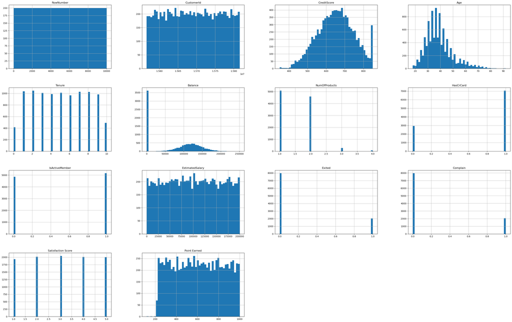

```python
# Visualise distributions of all columns
df.hist(bins=50, figsize=(40,25)) #Hist shows all columns as a histogram so we can visually tell which attributes are columns
```

```
Exited
0    79.62
1    20.38
Name: count, dtype: float64
```

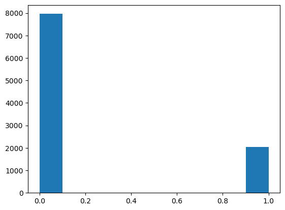

```python
# Check for Class Imbalance
plt.hist(df['Exited'],)
df.groupby(["Exited"])["Exited"].value_counts()/len(df)*100.00
```

```python
#function to identify multicollinear columns
def collinearity_rem(correlation_matrix, threshold):
    # Create a Mask

    collinear_pairs = []
    #traverse diagonal
    for i in range(1,correlation_matrix.shape[0]):
        for j in range(i):
            if abs(correlation_matrix.iloc[i,j]) > threshold:
                collinear_pairs.append((correlation_matrix.columns[i], correlation_matrix.columns[j]))

    print("Collinear pairs above threshold:")
    for pair in collinear_pairs:
        print(f"Variables {pair[0]} and {pair[1]} are highly correlated.")

    # Create a list of variables to remove (only 1 variable from each pair)
    variables_to_remove = set()
    for pair in collinear_pairs:
        variables_to_remove.add(pair[0])

    # Convert set to a list
    variables_to_remove = list(variables_to_remove)
        #converts matrix to a flatmap
    return variables_to_remove
```

### Data Cleansing and Pre-processing

```python
# Drop Sensitive Identifiers
df_cleaned = df.drop(['RowNumber','CustomerId','Surname'], axis=1)
```

```python
#Check Nulls
df.isnull().sum()
```

```
RowNumber             0
CustomerId            0
Surname               0
CreditScore           0
Geography             0
Gender                0
Age                   0
Tenure                0
Balance               0
NumOfProducts         0
HasCrCard             0
IsActiveMember        0
EstimatedSalary       0
Exited                0
Complain              0
Satisfaction Score    0
Card Type             0
Point Earned          0
dtype: int64
```

```python
# Addressing Censored data in Credit Score and Balance by introducing indicator variable (Feature Engineering)
df_cleaned["Credit_Score_Cap"] = df_cleaned["CreditScore"] == 850
df_cleaned["Balance_Cap"] = df_cleaned["Balance"] == 0
```

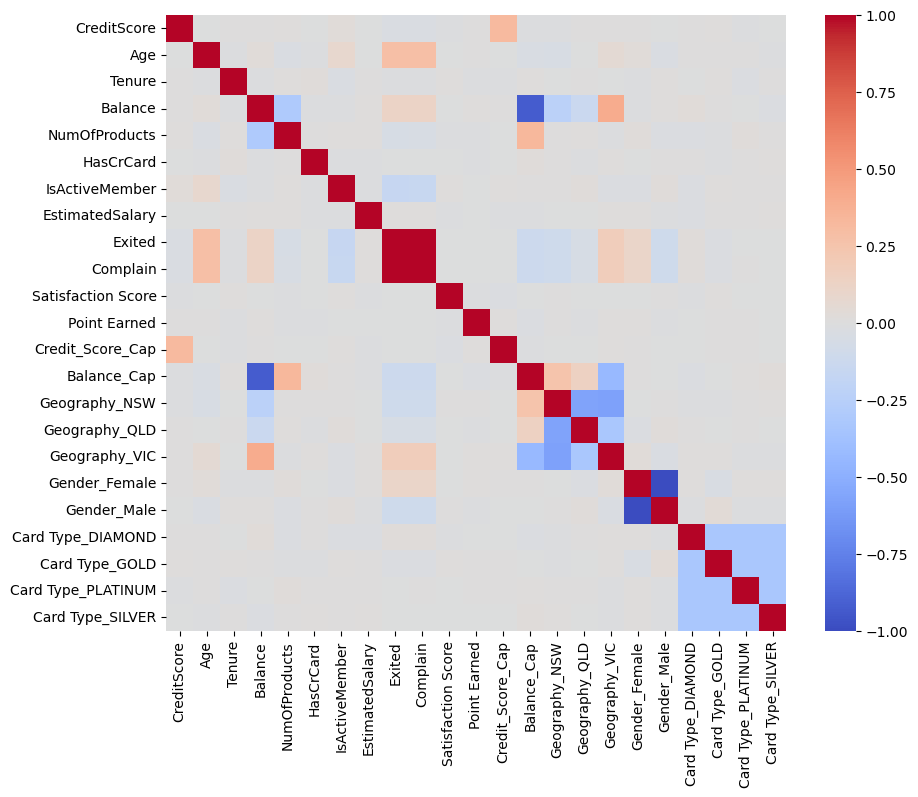

```python
#One hot-encode for categorical data
object_names = list(df_cleaned.dtypes[df_cleaned.dtypes == 'object'].index)

for i in object_names:
    encoded = pd.get_dummies(df_cleaned[i],prefix = i)
    df_cleaned = pd.concat([df_cleaned,encoded],axis=1)
    df_cleaned = df_cleaned.drop(i,axis=1)

df_cleaned.head()

# Removing Multicollinear data
corr_matrix = df_cleaned.corr()
plt.figure(figsize=(10,8))
sns.heatmap(corr_matrix,annot=False,cmap='coolwarm',fmt=".2f")
plt.show()

#Remove any column that has a multicollinearity > 75%
```

```python
collinearity_rem(corr_matrix.drop("Exited", axis=1).drop("Exited",axis=0),threshold=0.80)
```

```
Collinear pairs above threshold:
Variables Balance_Cap and Balance are highly correlated.
Variables Gender_Male and Gender_Female are highly correlated.
```

```
['Balance_Cap', 'Gender_Male']
```

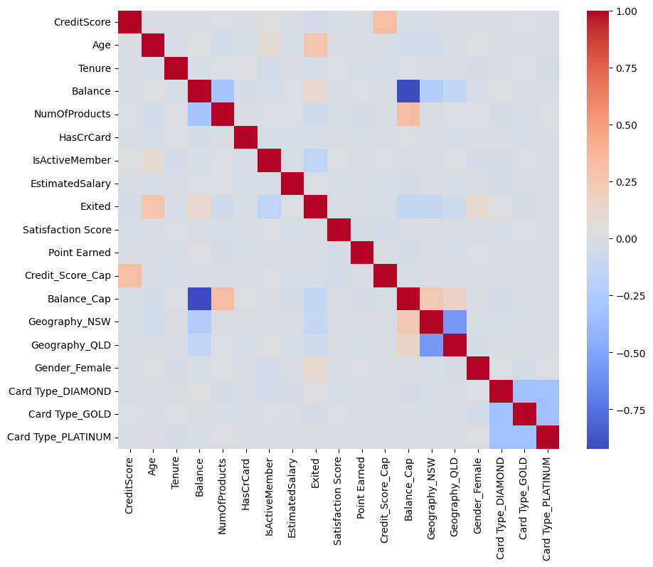

```python
df_cleaned = df_cleaned.drop(["Gender_Male","Complain", "Geography_VIC", "Card Type_SILVER"], axis = 1)
# Removing Multicollinear data
corr_matrix = df_cleaned.corr()
plt.figure(figsize=(10,8))
sns.heatmap(corr_matrix,annot=False,cmap='coolwarm',fmt=".2f")
plt.show()
```

### Fix Class Imbalance

```
<BarContainer object of 2 artists>
```

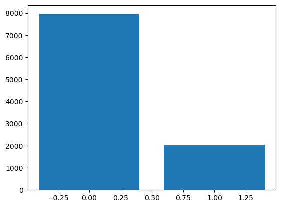

```python
#Plot the two classes
#Check for Class Imbalance
plt.bar(df_cleaned['Exited'].value_counts().index,df_cleaned['Exited'].value_counts().values)
```

```python
# 1) Define target and features
#df_cleaned['Exited']= df_cleaned['Exited'].apply(str)
X = df_cleaned.drop(["Exited"], axis=1) # Matrix of features excl. target
y = df_cleaned["Exited"] #Vector of the target feature
```

```python
# Addressing Class imbalance - Bootstrap to add more samples in the underrepresented class
smote_sample = SMOTE(sampling_strategy=1, k_neighbors=5, random_state=123)
X, y = smote_sample.fit_resample(X, y)
```

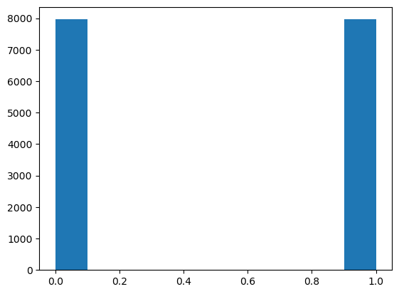

```python
# Check Distribution now
plt.hist(y)
```

```python
X.describe()
```

|  | CreditScore | Age | Tenure | Balance | NumOfProducts | HasCrCard | IsActiveMember | EstimatedSalary | Satisfaction Score | Point Earned |
| --- | --- | --- | --- | --- | --- | --- | --- | --- | --- | --- |
| count | 15924.000000 | 15924.000000 | 15924.000000 | 15924.000000 | 15924.000000 | 15924.000000 | 15924.000000 | 15924.000000 | 15924.000000 | 15924.000000 |
| mean | 648.297476 | 40.967910 | 4.825609 | 81729.913791 | 1.422758 | 0.626790 | 0.372017 | 100246.812533 | 2.849912 | 606.496609 |
| std | 91.777339 | 9.991067 | 2.721939 | 61343.524186 | 0.575188 | 0.483672 | 0.483358 | 57498.427624 | 1.328987 | 211.265903 |
| min | 350.000000 | 18.000000 | 0.000000 | 0.000000 | 1.000000 | 0.000000 | 0.000000 | 11.580000 | 1.000000 | 119.000000 |
| 25% | 586.000000 | 34.000000 | 3.000000 | 0.000000 | 1.000000 | 0.000000 | 0.000000 | 51356.326182 | 2.000000 | 430.000000 |
| 50% | 650.000000 | 40.000000 | 5.000000 | 102973.925000 | 1.000000 | 1.000000 | 0.000000 | 100639.598258 | 3.000000 | 606.000000 |
| 75% | 711.250000 | 47.000000 | 7.000000 | 129295.125000 | 2.000000 | 1.000000 | 1.000000 | 149656.770000 | 4.000000 | 781.000000 |
| max | 850.000000 | 92.000000 | 10.000000 | 250898.090000 | 4.000000 | 1.000000 | 1.000000 | 199992.480000 | 5.000000 | 1000.000000 |

### Model Data

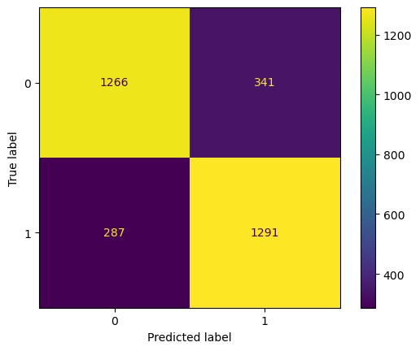

```
Model: Decision Tree
Accuracy: 0.8028257456828886
Recall: 0.8181242078580482
Precision: 0.7910539215686274
F1 Score: 0.8043613707165108
roc_auc_score 0.8029637840783707
```

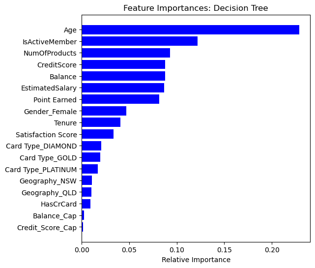

```
AUC: 0.8029637840783707
```

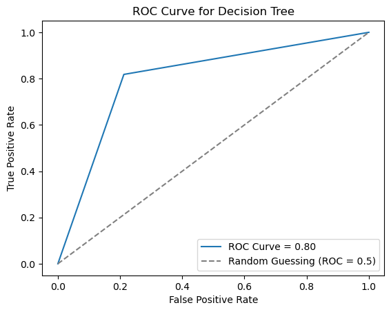

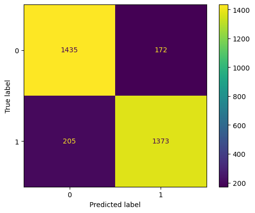

```
Model: Random Forest
Accuracy: 0.8816326530612245
Recall: 0.8700887198986058
Precision: 0.888673139158576
F1 Score: 0.8792827409542108
roc_auc_score 0.8815284918721404
```

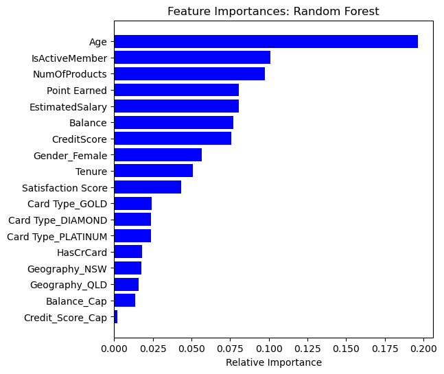

```
AUC: 0.9469104196390475
```

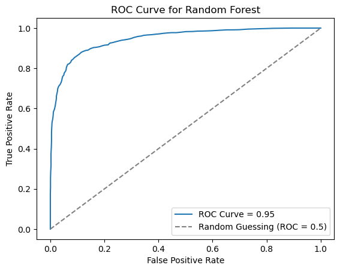

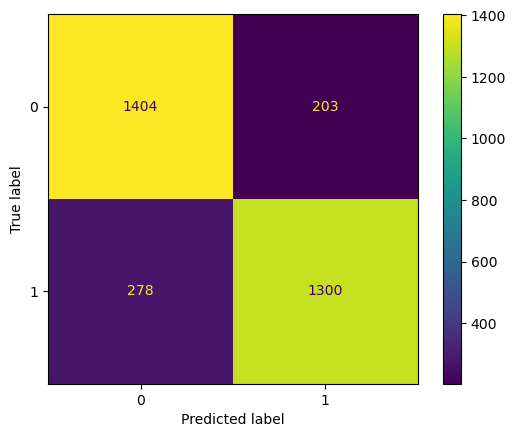

```
Model: Gradient Boost
Accuracy: 0.8489795918367347
Recall: 0.8238276299112801
Precision: 0.8649367930805056
F1 Score: 0.8438818565400844
roc_auc_score 0.8487526450738727
```

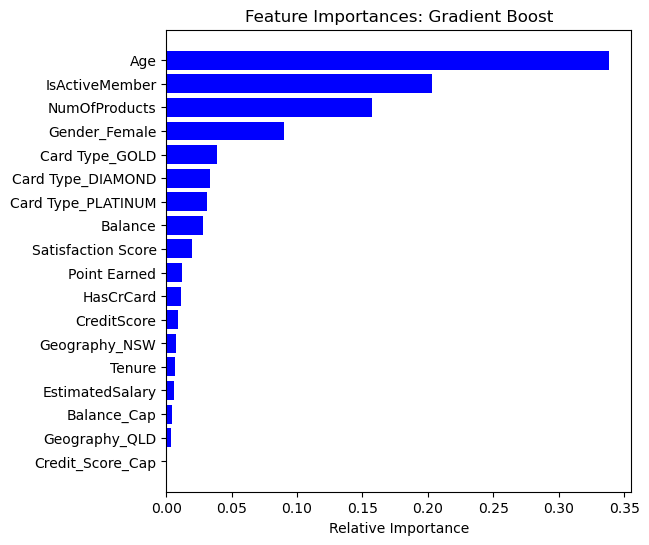

```
AUC: 0.9323653723451661
```

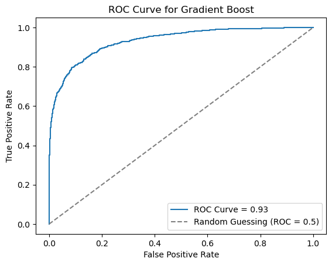

```python
# 2) Split Data Set
X_train, X_test, y_train, y_test = train_test_split(X, y, test_size=0.2, random_state=23)


# 3) Initiate your classifier objects
classifiers = [DecisionTreeClassifier(),RandomForestClassifier(),GradientBoostingClassifier()]
classifier_names = ['Decision Tree','Random Forest','Gradient Boost']

# 4) Store your prediction results and begin training your models
results_train = []
results_test = []
results = []

# 5) Print your evaluation metrics + Display feature important
for clf, name in zip(classifiers,classifier_names):
    pass
    #Train the model
    clf.fit(X_train,y_train)

    #Predict the responses using the trained model and store the predicted responses
    y_pred = clf.predict(X_test)
    y_pred_train = clf.predict(X_train)

    #Create a confusion matrix to evaluate
    cm = confusion_matrix(y_test,y_pred)

    #Visualise the confusion matrix
    plt.figure(figsize=(8,6))
    #sns.heatmap(cm, annot=True, cmap='Blues', fmt = 'g')
    ConfusionMatrixDisplay(cm, display_labels= clf.classes_).plot()
    plt.show()

    #Print evaluation metrics
    print(f"Model: {name}")
    print("Accuracy:", accuracy_score(y_test,y_pred))
    print("Recall:", recall_score(y_test,y_pred))
    print("Precision:", precision_score(y_test,y_pred))
    print("F1 Score:", f1_score(y_test,y_pred))
    print("roc_auc_score", roc_auc_score(y_test,y_pred))

    #Display feature importance
    importances = clf.feature_importances_
    indices = np.argsort(importances)

    plt.clf()
    plt.figure(figsize=(6,6))
    plt.title(f'Feature Importances: {name}')
    plt.barh(range(len(indices)), importances[indices], color='b', align='center')
    plt.yticks(range(len(indices)), [X.columns[i] for i in indices])
    plt.xlabel('Relative Importance')
    plt.show()
    plt.clf()

    # Y Scores for AUC Model
    y_scores_train = clf.predict_proba(X_train)[:,1]
    y_scores_test = clf.predict_proba(X_test)[:,1]

    # Calculate AUC
    auc = roc_auc_score(y_test, y_scores_test)
    print(f'AUC: {auc}')

    # Calculate and visualize ROC curve
    fpr, tpr, thresholds = roc_curve(y_test, y_scores_test, pos_label=0)
    plt.plot(tpr, fpr, label= f'ROC Curve = {auc:0.2f}')
    plt.plot([0, 1], [0, 1], linestyle='--', label='Random Guessing (ROC = 0.5)', color='gray')
    plt.xlabel('False Positive Rate')
    plt.ylabel('True Positive Rate')
    plt.title(f'ROC Curve for {name}')
    plt.legend()
    plt.show()

    #Evaluate and append results
    results_train.append({
        'Classifier': name,
        'Accuracy': accuracy_score(y_train,y_pred_train),
        'Precision': precision_score(y_train, y_pred_train),
        'Recall': recall_score(y_train, y_pred_train),
        'F1': f1_score(y_train, y_pred_train),
        'AUC': roc_auc_score(y_train,y_scores_train)
    })
    results_test.append({
        'Classifier': name,
        'Accuracy': accuracy_score(y_test,y_pred),
        'Precision': precision_score(y_test, y_pred),
        'Recall': recall_score(y_test, y_pred),
        'F1': f1_score(y_test, y_pred),
        'AUC': roc_auc_score(y_test,y_scores_test)
    })
```

```python
# Check Training Measures
pd.DataFrame(results_train).head()
```

|  | Classifier | Accuracy | Precision | Recall | F1 | AUC |
| --- | --- | --- | --- | --- | --- | --- |
| 0 | Decision Tree | 1.0000 | 1.000000 | 1.000000 | 1.000000 | 1.000000 |
| 1 | Random Forest | 1.0000 | 1.000000 | 1.000000 | 1.000000 | 1.000000 |
| 2 | Gradient Boost | 0.8609 | 0.874594 | 0.843358 | 0.858692 | 0.938751 |

```python
# Check Testing Measures
pd.DataFrame(results_test).head()
```

|  | Classifier | Accuracy | Precision | Recall | F1 | AUC |
| --- | --- | --- | --- | --- | --- | --- |
| 0 | Decision Tree | 0.802826 | 0.791054 | 0.818124 | 0.804361 | 0.802964 |
| 1 | Random Forest | 0.881633 | 0.888673 | 0.870089 | 0.879283 | 0.946910 |
| 2 | Gradient Boost | 0.848980 | 0.864937 | 0.823828 | 0.843882 | 0.932365 |

Part 2:

- Apply hyperparameter turning to optimise the parameters of your model
- Experiment with feature engineering techniques to create new features from the existing data
- Consider if the data quality enhancement or sampling techniques could help improve your model's performance

```
Best parameters for Decision Tree: {'max_depth': 9, 'min_samples_leaf': 13, 'min_samples_split': 2}/n
```

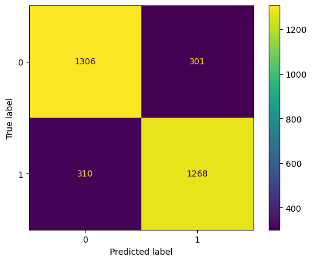

```
Accuracy: 0.8081632653061225
Precision: 0.8081580624601657
Recall: 0.8035487959442332
F1 score: 0.8058468382586591
Hyperparameter tuning took: 169.80 seconds
Best parameters for Random Forest: {'max_depth': None, 'min_samples_leaf': 1, 'min_samples_split': 2, 'n_estimators': 200}/n
```

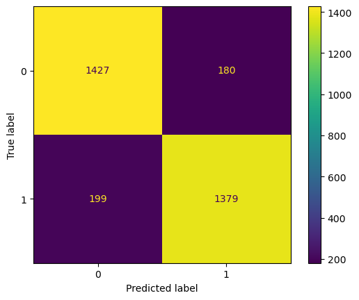

```
Accuracy: 0.8810047095761382
Precision: 0.8845413726747915
Recall: 0.8738910012674271
F1 score: 0.8791839336946127
Hyperparameter tuning took: 191.07 seconds
Best parameters for Gradient Boost: {'learning_rate': 0.1, 'max_depth': 10, 'min_samples_leaf': 4, 'min_samples_split': 10, 'n_estimators': 200}/n
```

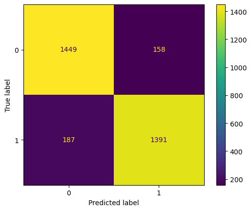

```
Accuracy: 0.8916797488226059
Precision: 0.8979987088444158
Recall: 0.8814955640050697
F1 score: 0.8896706108090823
Hyperparameter tuning took: 2823.50 seconds
```

```python
# 5) Initiate a grid search to improve training...

from sklearn.model_selection import GridSearchCV
import time

# Define the parameter grid

param_grid_dt = {
    'max_depth': np.arange(3, 15),
    'min_samples_split': np.arange(2, 15),
    'min_samples_leaf': np.arange(1, 15),
}

param_grid_gbm = {
    'n_estimators': [50, 100, 200],
    'learning_rate': [0.01, 0.1, 1],
       'max_depth': [None, 5, 10],
    'min_samples_split': [2, 5, 10],
    'min_samples_leaf': [1, 2, 4]
}

param_grid_rf = {
    'n_estimators': [50, 100, 200],
    'max_depth': [None, 5, 10],
    'min_samples_split': [2, 5, 10],
    'min_samples_leaf': [1, 2, 4]
}
best_params_all = dict()


# Create a Random Forest Classifier with the parameter grid
classifier_names = ['Decision Tree','Random Forest','Gradient Boost']

for clf, param_grid, name in zip(classifiers,[param_grid_dt,param_grid_rf,param_grid_gbm],classifier_names):
#for clf, param_grid in zip(classifiers,[param_grid_dt]):
    start_time = time.time()

    # Instantiate the grid search model
    grid_search = GridSearchCV(estimator=clf, param_grid=param_grid, cv=2)

    # Fit the grid search to the data
    grid_search.fit(X_train, y_train)

    end_time = time.time()
    elapsed_time = end_time - start_time

    # Get the best parameters
    best_params_all[name] = grid_search.best_params_

    print(f'Best parameters for {name}: {best_params_all[name]}/n')

    # Train the model with best parameters
    best_grid = grid_search.best_estimator_
    best_grid.fit(X_train, y_train)

    # Predict the response for the test dataset
    y_pred = best_grid.predict(X_test)

    # Create a confusion matrix
    cm = confusion_matrix(y_test, y_pred)
    cmd = ConfusionMatrixDisplay(cm)
    cmd.plot()
    plt.show()

    # Print evaluation metrics
    print("Accuracy:", accuracy_score(y_test, y_pred))
    print("Precision:", precision_score(y_test, y_pred))
    print("Recall:", recall_score(y_test, y_pred))
    print("F1 score:", f1_score(y_test, y_pred))

    print(f"Hyperparameter tuning took: {elapsed_time:.2f} seconds")
```